# A Study of Red Wine Features - Mike Cassell

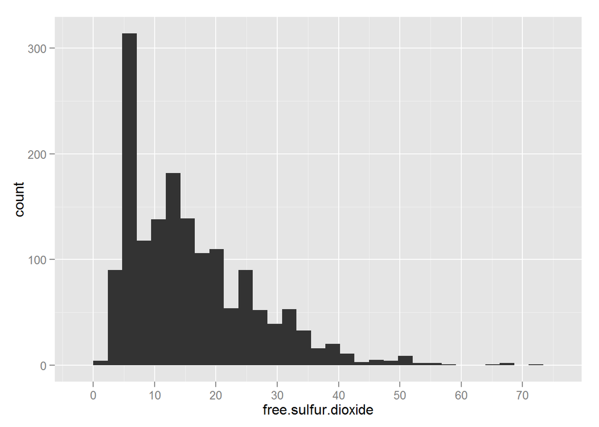

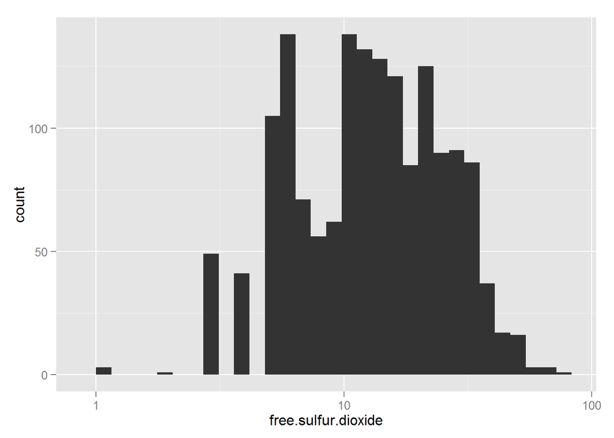

```
##    Min. 1st Qu.  Median    Mean 3rd Qu.    Max.
##    1.00    7.00   14.00   15.87   21.00   72.00
```

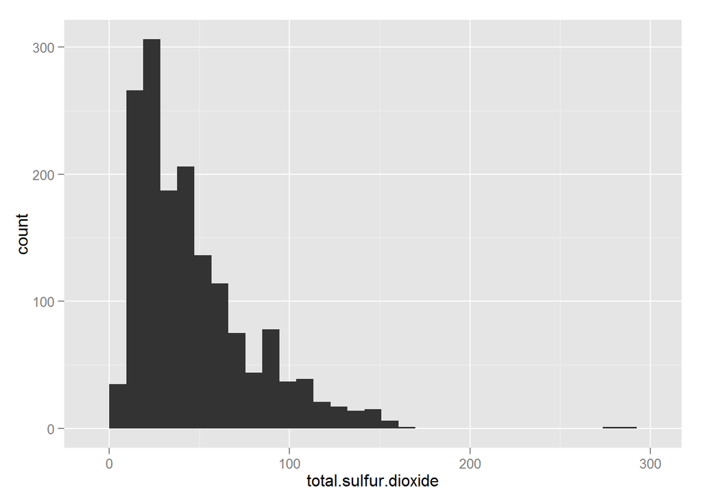

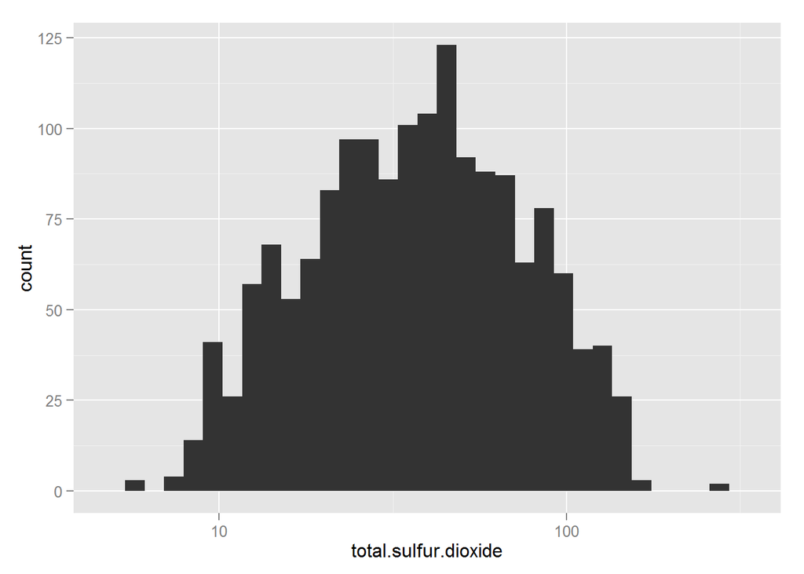

```
##    Min. 1st Qu.  Median    Mean 3rd Qu.    Max.
##    6.00   22.00   38.00   46.47   62.00  289.00
```

Sulfates: The middle 50% of the wines have between 7 and 21 g/dl3 of free sulfur dioxides although there are a small number of wines with much higher counts (up to 72). For total sulfur dioxide content, most wines have between 22 and 62 g/dl3 with a max of 289. This feature does transform to a somewhat normal distribution with a log10 scale adjustment.

# Univariate Analysis

### What is the structure of your dataset?

There are 1599 samples from red wines with 11 input variables and one output. The quality measure can be treated as an ordered factor from 1 to 10. While some of the features are somewhat normally distributed (some with transformations), there are others that don’t appear to be in any way (alcohol content.) There are many wines in the middle of the quality ratings and very few at the bottom which would suggest there isn’t as huge a variation as there could be (almost all of the wines are rated a 5 or 6.) Hopefully this will highlight a feature or two which are strongly correlated to a score of 7 or above.

### What is/are the main feature(s) of interest in your dataset?

I’m mostly interested in whether any of the input features will be useful in predicting the subjective quality rating of the wines. At this point I haven’t discovered any evidence to suggest any feature in particular.

### What other features in the dataset do you think will help support your investigation into your feature(s) of interest?

I think the other features (alcohol level, residual sugar) will play important roles but am also interested in both the ratio of different acids and the proportion of free vs. fixed sulfur as potential indicators of quality.

### Did you create any new variables from existing variables in the dataset?

Not yet but I intend to add a few during bi-variate analysis.

### Of the features you investigated, were there any unusual distributions? Did you perform any operations on the data to tidy, adjust, or change the form of the data? If so, why did you do this?

There were several features that had to be charted on a logarithmic scale to show a normal distribution due to long tails. The data set seems very complete and I haven’t had to modify it so far.

# Bivariate Plots Section

```
##                          X fixed.acidity volatile.acidity citric.acid
## X                     1.00         -0.27            -0.01       -0.15
## fixed.acidity        -0.27          1.00            -0.26        0.67
## volatile.acidity     -0.01         -0.26             1.00       -0.55
## citric.acid          -0.15          0.67            -0.55        1.00
## residual.sugar       -0.03          0.11             0.00        0.14
## chlorides            -0.12          0.09             0.06        0.20
## free.sulfur.dioxide   0.09         -0.15            -0.01       -0.06
## total.sulfur.dioxide -0.12         -0.11             0.08        0.04
## density              -0.37          0.67             0.02        0.36
## pH                    0.14         -0.68             0.23       -0.54
## sulphates            -0.13          0.18            -0.26        0.31
## alcohol               0.25         -0.06            -0.20        0.11
## quality               0.07          0.12            -0.39        0.23
##                      residual.sugar chlorides free.sulfur.dioxide
## X                             -0.03     -0.12                0.09
## fixed.acidity                  0.11      0.09               -0.15
## volatile.acidity               0.00      0.06               -0.01
## citric.acid                    0.14      0.20               -0.06
## residual.sugar                 1.00      0.06                0.19
## chlorides                      0.06      1.00                0.01
## free.sulfur.dioxide            0.19      0.01                1.00
## total.sulfur.dioxide           0.20      0.05                0.67
## density                        0.36      0.20               -0.02
## pH                            -0.09     -0.27                0.07
## sulphates                      0.01      0.37                0.05
## alcohol                        0.04     -0.22               -0.07
## quality                        0.01     -0.13               -0.05
##                      total.sulfur.dioxide density    pH sulphates alcohol
## X                                   -0.12   -0.37  0.14     -0.13    0.25
## fixed.acidity                       -0.11    0.67 -0.68      0.18   -0.06
## volatile.acidity                     0.08    0.02  0.23     -0.26   -0.20
## citric.acid                          0.04    0.36 -0.54      0.31    0.11
## residual.sugar                       0.20    0.36 -0.09      0.01    0.04
## chlorides                            0.05    0.20 -0.27      0.37   -0.22
## free.sulfur.dioxide                  0.67   -0.02  0.07      0.05   -0.07
## total.sulfur.dioxide                 1.00    0.07 -0.07      0.04   -0.21
## density                              0.07    1.00 -0.34      0.15   -0.50
## pH                                  -0.07   -0.34  1.00     -0.20    0.21
## sulphates                            0.04    0.15 -0.20      1.00    0.09
## alcohol                             -0.21   -0.50  0.21      0.09    1.00
## quality                             -0.19   -0.17 -0.06      0.25    0.48
##                      quality
## X                       0.07
## fixed.acidity           0.12
## volatile.acidity       -0.39
## citric.acid             0.23
## residual.sugar          0.01
## chlorides              -0.13
## free.sulfur.dioxide    -0.05
## total.sulfur.dioxide   -0.19
## density                -0.17
## pH                     -0.06
## sulphates               0.25
## alcohol                 0.48
## quality                 1.00
```

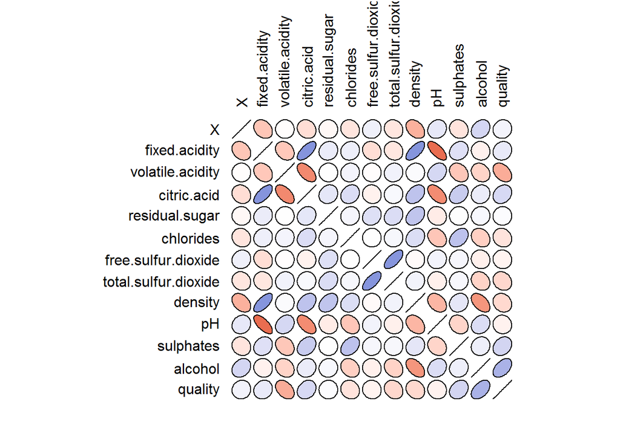

There aren’t any features that are very strongly related to the overall quality but there are some which seem like promising starts. The volatile acidity is negatively correlated with a factor of -0.39, and the citric acid, sulfates and alcohol are all positively correlated to varying degrees.

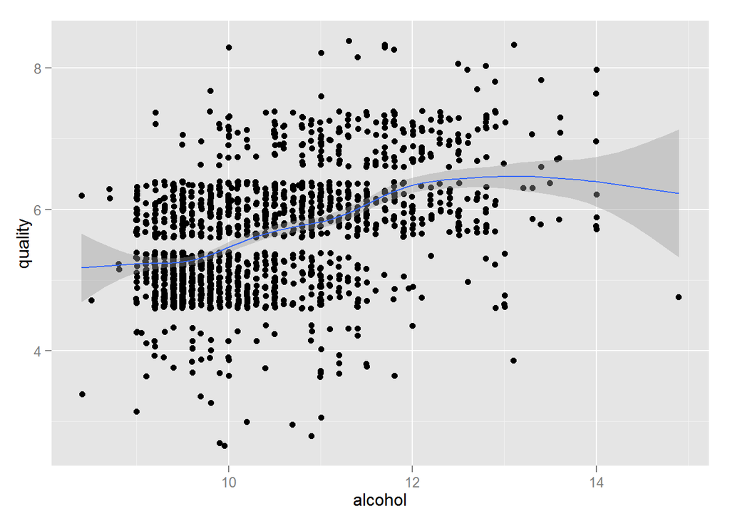

The alcohol content does show a positive correlation but there are still a lot of points that don’t fit with this relationship completely. There are exceptions in both directions (e.g. an 8 rated wine with less than 10% alcohol and a 5 rated wine is actually the highest alcohol content wine.)

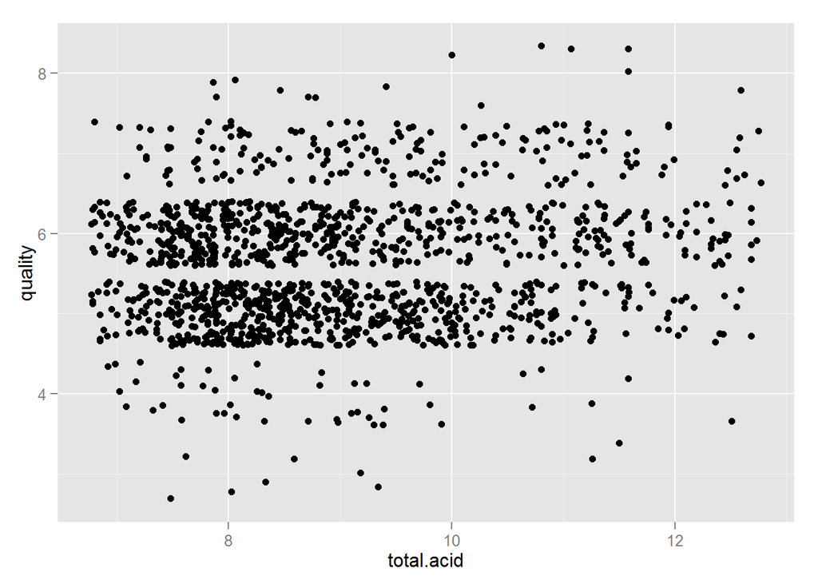

I created a feature to show the total acidic content of the wines, nothing strong stands out with the this relationship.

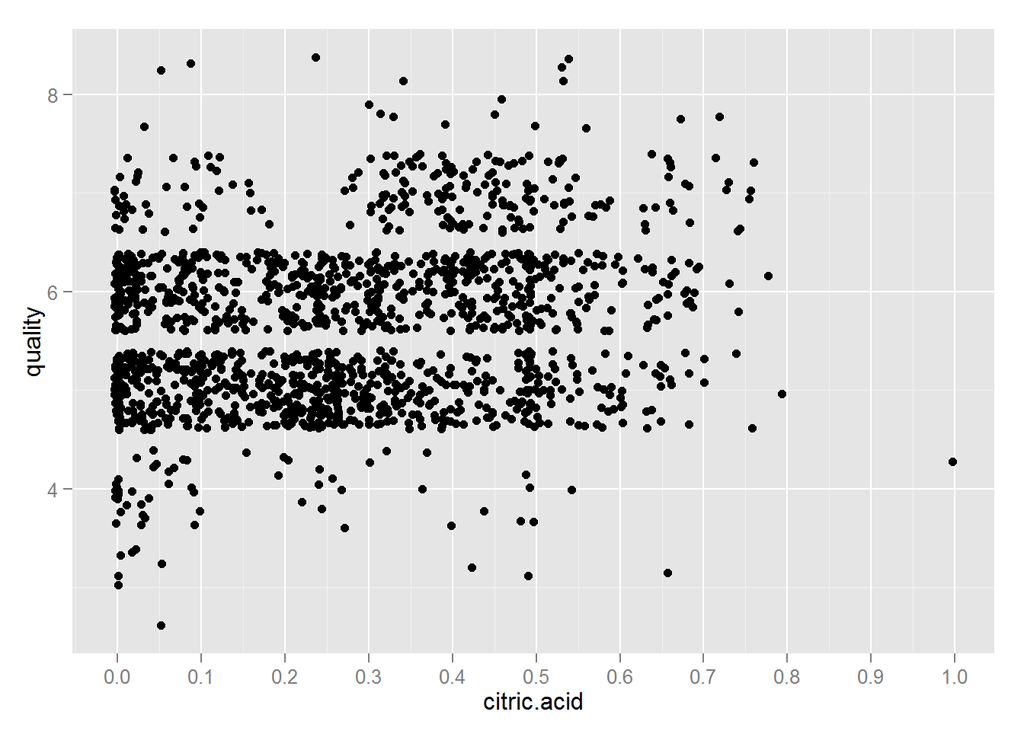

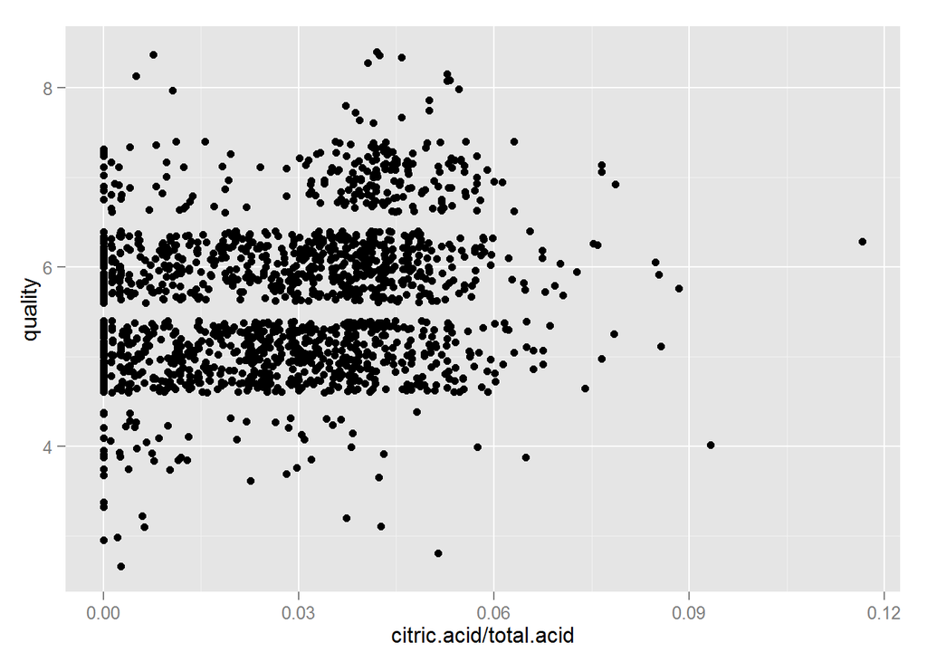

Nothing stands out with the citric acid concentrations, either as a measure or as a ratio of total acid content.

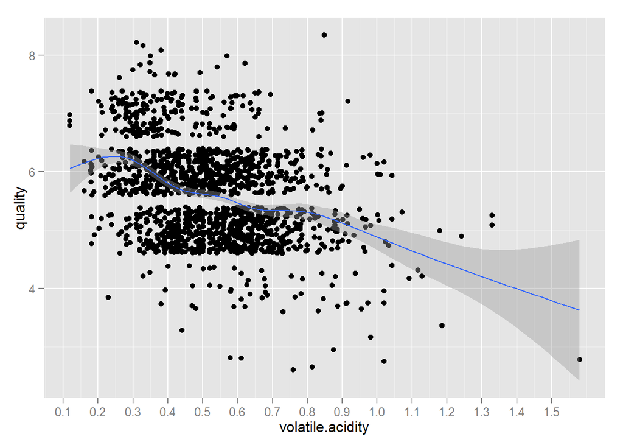

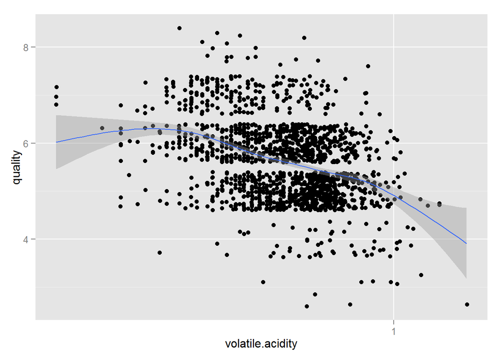

There appears to be a negative correlation between the volatile acidity and the quality of a wine overall. Interesting to note is that there are at least a few highly rated wines with high volatile acidity levels indicating the relationship may be complex and influenced by several factors.

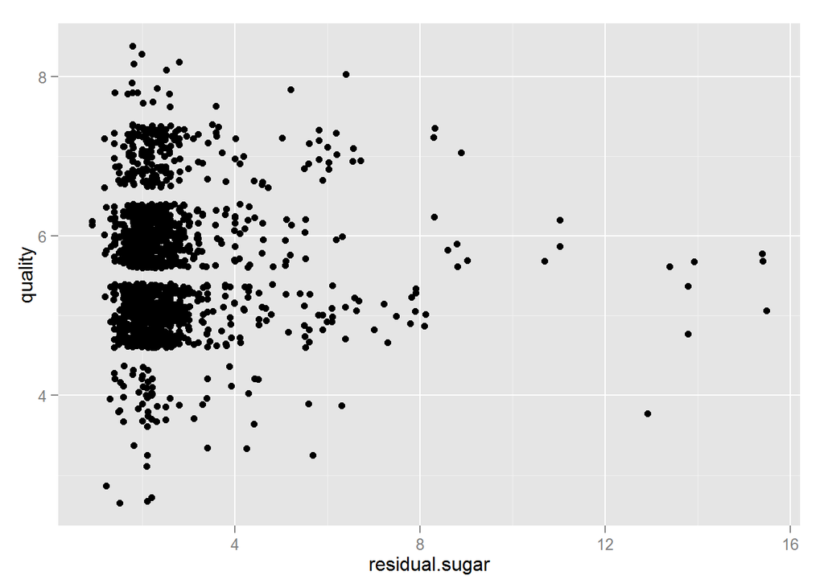

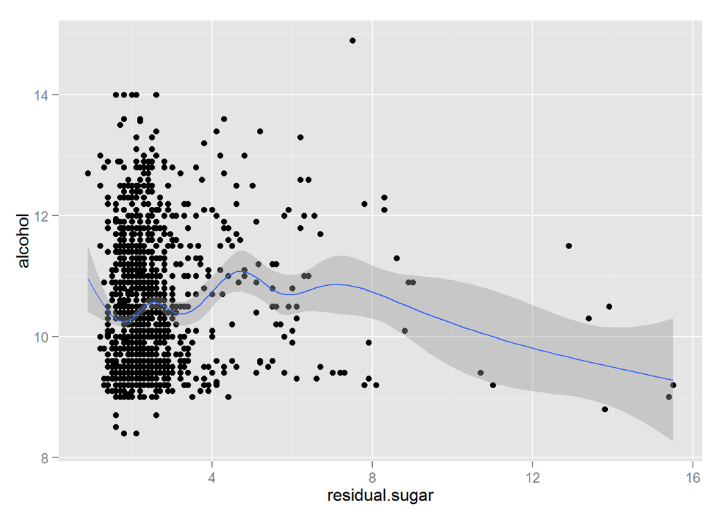

There is no clear relationship between the residual sugar levels and the alcohol content.

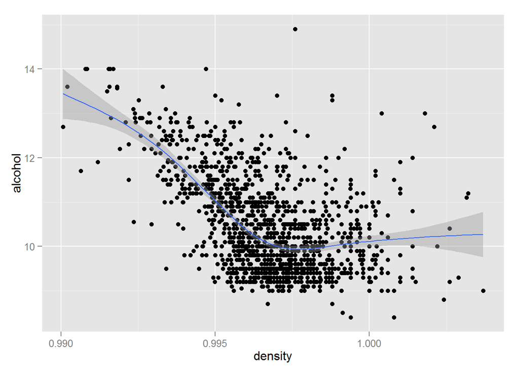